# Result notes

Yuta Suzuki

4/23/2021

# Article information

Yuta Suzuki, Minami Tetsuto, Shigeki Nakauchi

*Corresponding author: Yuta Suzuki

# Figure 1

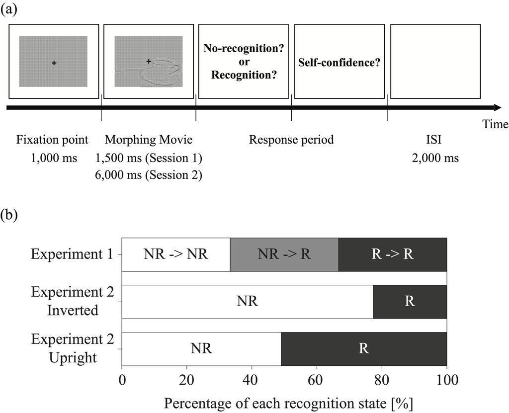

Figure 1. Experimental design and the percentage of each recognition state. (a) Protocol for Experiment 1. In each trial, a fixation point was presented for 1,000 ms prior to presentation of the stimulus. Each movie was presented for 1,500 ms in the first session and 6,000 ms in the second session. Each trial was separated by an inter-stimulus interval (ISI) of 2,000 ms. Participants reported whether they were able to recognize the contents of the movie following each trial using the keypad. (b) This percentage represents the averaged trial ratio of each recognition state among participants: PNN, PNR, and PRR conditions. All trials consisted of 60 movies in Experiment 1 and 40 movies in Experiment 2. Therefore, 100% denotes the total number of trials for which responses were provided.